# Python Data Science Toolbox (Part 2)

- William Surles
- 2017-10-17
- Datacamp notes

```python
import pandas as pd
import matplotlib.pyplot as plt
pd.options.mode.chained_assignment = None  # default='warn'
```

# Using iterators in PythonLand

## Introduction to iterators

#### Iterating with a for loop...

```python
# iterating over a list
employees = ['Nick', 'Lore', 'Hugo']
for employee in employees:
    print(employee)
```

```
Nick
Lore
Hugo
```

```python
# iterating over a string
for letter in 'DataCamp':
    print(letter)
```

```
D
a
t
a
C
a
m
p
```

```python
# Iterating over a range
for i in range(4):
    print(i)
```

```
0
1
2
3
```

- We can loop over these objects because they are iterables in python
- Iterable
  - lists, strings, dictiionaries, file connections
  - An object with an associated `iter()` method
  - Applying `iter()` to an iterable creates an iterator
  - This is what a `for` loop is actually doing under the hood
- Iterator
  - Produces next value with `next()` method

#### A quick example of how `iter()` works...

```python
word = 'Dad'
it = iter(word)
print(next(it))
print(next(it))
print(next(it))
```

```
D
a
d
```

#### Iterating at once with *

- Note: this will only work once and then there are not more items to iterator over
- You will need to redefine `it` to do this again

```python
word = 'Data'
it = iter(word)
print(*it)
print('again?...')
print(*it)
```

```
D a t a
again?...
```

#### Iterating over dictionaries

```python
pythonistas = {'hugo':'browne-anderson', 'francis':'castrp'}

for key, value in pythonistas.items():
    print(key, value)
```

```
hugo browne-anderson
francis castrp
```

#### Iterating over file connections

```python
file = open('simple_file.txt')
it = iter(file)
print(next(it))
print(next(it))
print(next(it))
print(next(it))
```

```
This is the first line.

This is the second.

And the third.

Thats all.
```

### Iterators vs Iterables

```python
flash1 = ['jay garrick', 'barry allen', 'wally west', 'bart allen']

print(flash1)
print(next(flash1))
```

```
['jay garrick', 'barry allen', 'wally west', 'bart allen']
```

```
---------------------------------------------------------------------------
TypeError                                 Traceback (most recent call last)
<ipython-input-19-29eae0d6cf7f> in <module>()
      2
      3 print(flash1)
----> 4 print(next(flash1))

TypeError: 'list' object is not an iterator
```

```python
flash2 = iter(flash1)

print(flash2)
print(next(flash2))
print(next(flash2))
```

```
<list_iterator object at 0x107610828>
jay garrick
barry allen
```

### Iterating over iterables (1)

```python
# Create a list of strings: flash
flash = ['jay garrick', 'barry allen', 'wally west', 'bart allen']

# Print each list item in flash using a for loop
for person in flash:
    print(person)
```

```
jay garrick
barry allen
wally west
bart allen
```

```python
# Create an iterator for flash: superspeed
superspeed = iter(flash)

# Print each item from the iterator
print(next(superspeed))
print(next(superspeed))
print(next(superspeed))
print(next(superspeed))
```

```
jay garrick
barry allen
wally west
bart allen
```

### Iterating over iterables (2)

```python
# Create an iterator for range(3): small_value
small_value = iter(range(3))

# Print the values in small_value
print(next(small_value))
print(next(small_value))
print(next(small_value))
```

```
0
1
2
```

```python
# Loop over range(3) and print the values
for num in range(3):
    print(num)
```

```
0
1
2
```

```python
# Create an iterator for range(10 ** 100): googol
googol = iter(range(10 ** 100))

# Print the first 5 values from googol
print(next(googol))
print(next(googol))
print(next(googol))
print(next(googol))
print(next(googol))
```

```
0
1
2
3
4
```

### Iterators as function arguments

```python
# Create a range object: values
values = range(10,21)

# Print the range object
print(values)
```

```
range(10, 21)
```

```python
# Create a list of integers: values_list
values_list = list(values)

# Print values_list
print(values_list)
```

```
[10, 11, 12, 13, 14, 15, 16, 17, 18, 19, 20]
```

```python
# Get the sum of values: values_sum
values_sum = sum(values)

# Print values_sum
print(values_sum)
```

```
165
```

## Playing with iterators

#### Using enumerate()

- `enumerate()` returns an `enumerate` object that produces a sequence of tuples, and each of the tuples is an index-value pair.

```python
avengers = ['hawkeye', 'iron man', 'thor', 'quicksilver']
e = enumerate(avengers)
print(type(e))

e_list = list(e)
print(e_list)
```

```
<class 'enumerate'>
[(0, 'hawkeye'), (1, 'iron man'), (2, 'thor'), (3, 'quicksilver')]
```

#### enumerate() and unpack

```python
avengers = ['hawkeye', 'iron man', 'thor', 'quicksilver']

for index, value in enumerate(avengers):
    print(index, value)
```

```
0 hawkeye
1 iron man
2 thor
3 quicksilver
```

```python
for index, value in enumerate(avengers, start = 10):
    print(index, value)
```

```
10 hawkeye
11 iron man
12 thor
13 quicksilver
```

#### Using zip()

- `zip()` takes any number of iterables and returns a zip object that is an iterator of tuples.
  - If you wanted to print the values of a zip object, you can convert it into a list and then print it.
  - Printing just a zip object will not return the values unless you unpack it first.

```python
avengers = ['hawkeye', 'iron man', 'thor', 'quicksilver']
names = ['barton', 'stark', 'odinson', 'maximoff']

z = zip(avengers, names)
print(type(z))

z_list = list(z)
print(z_list)
```

```
<class 'zip'>
[('hawkeye', 'barton'), ('iron man', 'stark'), ('thor', 'odinson'), ('quicksilver', 'maximoff')]
```

#### Print zip with *

```python
z = zip(avengers, names)
print(*z)
```

```
('hawkeye', 'barton') ('iron man', 'stark') ('thor', 'odinson') ('quicksilver', 'maximoff')
```

### Using enumerate

```python
# Create a list of strings: mutants
mutants = ['charles xavier',
            'bobby drake',
            'kurt wagner',
            'max eisenhardt',
            'kitty pride']

# Create a list of tuples: mutant_list
mutant_list = list(enumerate(mutants))

# Print the list of tuples
print(mutant_list)
```

```
[(0, 'charles xavier'), (1, 'bobby drake'), (2, 'kurt wagner'), (3, 'max eisenhardt'), (4, 'kitty pride')]
```

```python
# Unpack and print the tuple pairs
for index1, value1 in mutant_list:
    print(index1, value1)
```

```
0 charles xavier
1 bobby drake
2 kurt wagner
3 max eisenhardt
4 kitty pride
```

```python
# Change the start index
for index2, value2 in enumerate(mutants, start = 1):
    print(index2, value2)
```

```
1 charles xavier
2 bobby drake
3 kurt wagner
4 max eisenhardt
5 kitty pride
```

### Using zip

```python
mutants = ['charles xavier',
 'bobby drake',
 'kurt wagner',
 'max eisenhardt',
 'kitty pride']
aliases = ['prof x', 'iceman', 'nightcrawler', 'magneto', 'shadowcat']
powers = ['telepathy',
 'thermokinesis',
 'teleportation',
 'magnetokinesis',
 'intangibility']

# Create a list of tuples: mutant_data
mutant_data = list(zip(mutants, aliases, powers))

# Print the list of tuples
print(mutant_data)
```

```
[('charles xavier', 'prof x', 'telepathy'), ('bobby drake', 'iceman', 'thermokinesis'), ('kurt wagner', 'nightcrawler', 'teleportation'), ('max eisenhardt', 'magneto', 'magnetokinesis'), ('kitty pride', 'shadowcat', 'intangibility')]
```

```python
# Create a zip object using the three lists: mutant_zip
mutant_zip = zip(mutants, aliases, powers)

# Print the zip object
print(mutant_zip)

# Unpack the zip object and print the tuple values
for value1, value2, value3 in mutant_zip:
    print(value1, value2, value3)
```

```
<zip object at 0x107625148>
charles xavier prof x telepathy
bobby drake iceman thermokinesis
kurt wagner nightcrawler teleportation
max eisenhardt magneto magnetokinesis
kitty pride shadowcat intangibility
```

### Using * and zip to 'unzip'

```python
mutants = ('charles xavier',
 'bobby drake',
 'kurt wagner',
 'max eisenhardt',
 'kitty pride')
powers = ('telepathy',
 'thermokinesis',
 'teleportation',
 'magnetokinesis',
 'intangibility')

# Create a zip object from mutants and powers: z1
z1 = zip(mutants, powers)

# Print the tuples in z1 by unpacking with *
print(*z1)
```

```
('charles xavier', 'telepathy') ('bobby drake', 'thermokinesis') ('kurt wagner', 'teleportation') ('max eisenhardt', 'magnetokinesis') ('kitty pride', 'intangibility')
```

```python
# Re-create a zip object from mutants and powers: z1
z1 = zip(mutants, powers)

# 'Unzip' the tuples in z1 by unpacking with * and zip(): result1, result2
result1, result2 = zip(*z1)

print(result1)
print(result2)

# Check if unpacked tuples are equivalent to original tuples
print(result1 == mutants)
print(result2 == powers)
```

```
('charles xavier', 'bobby drake', 'kurt wagner', 'max eisenhardt', 'kitty pride')
('telepathy', 'thermokinesis', 'teleportation', 'magnetokinesis', 'intangibility')
True
True
```

## Using iterators to load large files into memory

- The object created by read_csv is an iterator, so I can iterate over it using a for loop.
- Each chunk will be a data frame
- we can perform a calculation on this chunk and append to result
- then we can take the sum of result to get the sum of the value for all the chunks.

```python
result = []

for chunk in pd.read_csv('data.csv', chuncksize = 1000):
    result.append(sum(chunk['x']))

total = sum(result)
print(total)
```

Another way to do this is to just add the sum total in each iteration

```python
total = 0

for chunk in pd.read_csv('data.csv', chuncksize = 1000):
    total += sum(chunk['x'])

print(total)
```

### Processing large amounts of Twitter data

```python
tweets_file = 'https://assets.datacamp.com/production/course_1531/datasets/tweets.csv'

# Initialize an empty dictionary: counts_dict
counts_dict = {}

# Iterate over the file chunk by chunk
for chunk in pd.read_csv(tweets_file, chunksize = 10):

    # Iterate over the column in DataFrame
    for entry in chunk['lang']:
        if entry in counts_dict.keys():
            counts_dict[entry] += 1
        else:
            counts_dict[entry] = 1

# Print the populated dictionary
print(counts_dict)
```

```
{'en': 97, 'et': 1, 'und': 2}
```

### Extracting information for large amounts of Twitter data

```python
# Define count_entries()
def count_entries(csv_file, c_size, colname):
    """Return a dictionary with counts of
    occurrences as value for each key."""

    # Initialize an empty dictionary: counts_dict
    counts_dict = {}

    # Iterate over the file chunk by chunk
    for chunk in pd.read_csv(csv_file, chunksize = c_size):

        # Iterate over the column in DataFrame
        for entry in chunk[colname]:
            if entry in counts_dict.keys():
                counts_dict[entry] += 1
            else:
                counts_dict[entry] = 1

    # Return counts_dict
    return counts_dict

# Call count_entries(): result_counts
result_counts = count_entries(tweets_file, c_size=10, colname='lang')

# Print result_counts
print(result_counts)
```

```
{'en': 97, 'et': 1, 'und': 2}
```

# List comprehensions and generators

## List comprehensions

#### For loops

- For loops are inefficient computationally and in terms of coding time and space.

```python
nums = [12, 8, 21, 3, 16]
```

```python
new_nums = []

for num in nums:
    new_nums.append(num + 1)

print(new_nums)
```

```
[13, 9, 22, 4, 17]
```

#### List comprehension with list

- Here is the same thing but with a list comprehension

```python
new_nums = [num + 1 for num in nums]

print(new_nums)
```

```
[13, 9, 22, 4, 17]
```

#### List comprehension with `range()`

- You can write a list comprehension over any iterable

```python
result = [num for num in range(11)]
print(result)
```

```
[0, 1, 2, 3, 4, 5, 6, 7, 8, 9, 10]
```

#### List comprehensions summary

- Collapse for loops for building lists into a single line
- Components
  - Iterable
  - Iterator variable (represent members of iterable)
  - Output expression

result = [`output expression` for `iterator variable` in `iterable`]

#### Nested loops

```python
pairs_1 = []

for num1 in range(0,2):
    for num2 in range(6,8):
        pairs_1.append((num1, num2))

print(pairs_1)
```

```
[(0, 6), (0, 7), (1, 6), (1, 7)]
```

List comprehension equivolent

```python
pairs_2 = [(num1, num2) for num1 in range(0,2) for num2 in range(6,8)]
print(pairs_2)
```

```
[(0, 6), (0, 7), (1, 6), (1, 7)]
```

- Note that list comprehension are not as readable.
  - They look a lot like the math expressions of a function so in that sense they are readable to mathematicians maybe
  - But its not as easy for everyone to read so consider the context and code audience when using them

### Write a basic list comprehension

```python
# write a list comprehension that takes the first letter of each name

doctor = ['house', 'cuddy', 'chase', 'thirteen', 'wilson']

[doc[0] for doc in doctor]
```

```
['h', 'c', 'c', 't', 'w']
```

### List comprehension over iterables

- List comprehensions can be built over lists, ranges, strings
- It can not be bult over an integer or float

### Writing list comprehensions

```python
# Create list comprehension: squares
squares = [i**2 for i in range(0,10)]
squares
```

```
[0, 1, 4, 9, 16, 25, 36, 49, 64, 81]
```

### Nested list comprehensions

```python
# Create a 5 x 5 matrix using a list of lists: matrix
matrix = [[col for col in range(0,5)] for row in range(0,5)]

# Print the matrix
for row in matrix:
    print(row)
```

```
[0, 1, 2, 3, 4]
[0, 1, 2, 3, 4]
[0, 1, 2, 3, 4]
[0, 1, 2, 3, 4]
[0, 1, 2, 3, 4]
```

## Advanced comprehensions

#### Conditionals on the iterable

```python
[num ** 2 for num in range(10) if num % 2 == 0]
```

```
[0, 4, 16, 36, 64]
```

#### Conditionals on the output expression

```python
[num ** 2 if num % 2 == 0 else 0 for num in range(10)]
```

```
[0, 0, 4, 0, 16, 0, 36, 0, 64, 0]
```

#### Dictionary comprehensions

```python
pos_neg = {num:-num for num in range(9)}
print(pos_neg)
print(type(pos_neg))
```

```
{0: 0, 1: -1, 2: -2, 3: -3, 4: -4, 5: -5, 6: -6, 7: -7, 8: -8}
<class 'dict'>
```

### Using conditionals in comprehensions (1)

[ `output expression` for `iterator variable` in `iterable` if `predicate expression` ]

```python
# Create a list of strings: fellowship
fellowship = ['frodo', 'samwise', 'merry', 'aragorn', 'legolas', 'boromir', 'gimli']

# Create list comprehension: new_fellowship
new_fellowship = [ member for member in fellowship if len(member) >= 7 ]

# Print the new list
print(new_fellowship)
```

```
['samwise', 'aragorn', 'legolas', 'boromir']
```

### Using conditionals in comprehensions (2)

```python
# Create a list of strings: fellowship
fellowship = ['frodo', 'samwise', 'merry', 'aragorn', 'legolas', 'boromir', 'gimli']

# Create list comprehension: new_fellowship
new_fellowship = [member if len(member) >=7 else "" for member in fellowship]

# Print the new list
print(new_fellowship)
```

```
['', 'samwise', '', 'aragorn', 'legolas', 'boromir', '']
```

### Dict comprehensions

```python
# Create a list of strings: fellowship
fellowship = ['frodo', 'samwise', 'merry', 'aragorn', 'legolas', 'boromir', 'gimli']

# Create dict comprehension: new_fellowship
new_fellowship = {member:len(member) for member in fellowship}

# Print the new list
print(new_fellowship)
```

```
{'frodo': 5, 'samwise': 7, 'merry': 5, 'aragorn': 7, 'legolas': 7, 'boromir': 7, 'gimli': 5}
```

## Introduction to generator expressions

#### Simple generator expression

```python
# This is a list comprehension. It uses []
[2 * num for num in range(10)]
```

```
[0, 2, 4, 6, 8, 10, 12, 14, 16, 18]
```

```python
# This is a generator expression. It uses ()
(2 * num for num in range(10))
```

```
<generator object <genexpr> at 0x1036d0f68>
```

#### List comprehensions vs generators

- List comprehensions return a list
- Generators return a generator object
- Both can be iterated over
- The generator is not stored in memory like a list.
  - It can be used for lazy evaluation
  - The evaluation of the expression is delayed until the value is needed.

#### Printing values from generators

```python
result = (num for num in range(6))
print(result)

for num in result:
    print(num)
```

```
<generator object <genexpr> at 0x103726a40>
0
1
2
3
4
5
```

```python
result = (num for num in range(6))
print(next(result))
print(next(result))
print(next(result))
print(next(result))
```

```
0
1
2
3
```

#### Generators for large seqences

```python
# This would never work for a list because this list is too big to be stored in memory
(num for num in range(10*1000000))
```

```
<generator object <genexpr> at 0x10377b938>
```

#### Conditionals in generator expressions

- Anything you can do with a list (filters and conditionals) we can do in a generator expression

```python
even_nums = (num for num in range(10) if num % 2 == 0)
print(list(even_nums))
```

```
[0, 2, 4, 6, 8]
```

#### Generator functions

- These are functions that when called produce generator objects
- They are defined like any other user defined function
  - Except they use `yield` instead of `return`

```python
# A simple generator function to create a list of numbers
def num_sequence(n):
    """Generate values fro 0 to n"""
    i = 0
    while i < n:
        yield i
        i +=1
```

#### Use a generator function

```python
# See, it makes a generator if we call it.
num_sequence(5)
```

```
<generator object num_sequence at 0x10377bfc0>
```

```python
# We can create a list with this generator
list(num_sequence(5))
```

```
[0, 1, 2, 3, 4]
```

```python
# or step through it and print out the numbers
nums = num_sequence(6)

for num in nums:
    print(num)
```

```
0
1
2
3
4
5
```

### Write your own generator expressions

```python
# Create generator object: result
result = (num for num in range(10))

# Print the first 5 values
print(next(result))
print(next(result))
print(next(result))
print(next(result))
print(next(result))

# Print the rest of the values
for value in result:
    print(value)
```

```
0
1
2
3
4
5
6
7
8
9
```

### Changing the output in generator expressions

```python
# Create a list of strings: lannister
lannister = ['cersei', 'jaime', 'tywin', 'tyrion', 'joffrey']

# Create a generator object: lengths
lengths = (len(person) for person in lannister)

# Iterate over and print the values in lengths
for value in lengths:
    print(value)
```

```
6
5
5
6
7
```

### Build a generator

```python
# Create a list of strings
lannister = ['cersei', 'jaime', 'tywin', 'tyrion', 'joffrey']

# Define generator function get_lengths
def get_lengths(input_list):
    """Generator function that yields the
    length of the strings in input_list."""

    # Yield the length of a string
    for person in input_list:
        yield len(person)


# Print the values generated by get_lengths()
for value in get_lengths(lannister):
    print(value)
```

```
6
5
5
6
7
```

## Wrapping up comprehensions and generators.

### List comprehensions for time-stamped data

```python
tweets_df = pd.read_csv('https://assets.datacamp.com/production/course_1531/datasets/tweets.csv')

# Extract the created_at column from df: tweet_time
tweet_time = tweets_df['created_at']

type(tweet_time)
```

```
pandas.core.series.Series
```

```python
# Extract the clock time: tweet_clock_time
tweet_clock_time = [entry[11:19] for entry in tweet_time]

# Print the extracted times
print(tweet_clock_time)
```

```
['23:40:17', '23:40:17', '23:40:17', '23:40:17', '23:40:17', '23:40:17', '23:40:18', '23:40:17', '23:40:18', '23:40:18', '23:40:18', '23:40:17', '23:40:18', '23:40:18', '23:40:17', '23:40:18', '23:40:18', '23:40:17', '23:40:18', '23:40:17', '23:40:18', '23:40:18', '23:40:18', '23:40:18', '23:40:17',…
```

### Conditional list comprehensions for time-stamped data

```python
# Extract the clock time: tweet_clock_time
tweet_clock_time = [entry[11:19] for entry in tweet_time if entry[17:19] == '19']

# Print the extracted times
print(tweet_clock_time)
```

```
['23:40:19', '23:40:19', '23:40:19', '23:40:19', '23:40:19', '23:40:19', '23:40:19', '23:40:19', '23:40:19', '23:40:19', '23:40:19', '23:40:19', '23:40:19', '23:40:19', '23:40:19', '23:40:19', '23:40:19', '23:40:19', '23:40:19', '23:40:19', '23:40:19', '23:40:19', '23:40:19', '23:40:19', '23:40:19',…
```

# Bringing it all together!

## Welcome to the case study!

### Dictionaries for data science

- First I need to load the world bank data.
- It is already in a pandas dataframe when loading with `read_csv`
- But for the exercises I need to pull out the data into list so we can reconstruct the dataframe. sigh.

```python
df_wb = pd.read_csv('https://assets.datacamp.com/production/course_1531/datasets/world_ind_pop_data.csv')
print(type(df_wb))
print(df_wb.head())
```

```
<class 'pandas.core.frame.DataFrame'>
                               CountryName CountryCode  Year  \
0                               Arab World         ARB  1960
1                   Caribbean small states         CSS  1960
2           Central Europe and the Baltics         CEB  1960
3  East Asia & Pacific (all income levels)         EAS  1960
4    East Asia & Pacific (developing only)         EAP  1960

   Total Population  Urban population (% of total)
0      9.249590e+07                      31.285384
1      4.190810e+06                      31.597490
2      9.140158e+07                      44.507921
3      1.042475e+09                      22.471132
4      8.964930e+08                      16.917679
```

```python
feature_names = list(df_wb)
feature_names
```

```
['CountryName',
 'CountryCode',
 'Year',
 'Total Population',
 'Urban population (% of total)']
```

```python
row_vals = list(df_wb.iloc[0,:])
row_vals
```

```
['Arab World', 'ARB', 1960, 92495902.0, 31.285384211605397]
```

```python
# Zip lists: zipped_lists
zipped_lists = zip(feature_names, row_vals)
type(zipped_lists)

# Create a dictionary: rs_dict
rs_dict = dict(zipped_lists)
type(rs_dict)

# Print the dictionary
print(rs_dict)
```

```
{'CountryName': 'Arab World', 'CountryCode': 'ARB', 'Year': 1960, 'Total Population': 92495902.0, 'Urban population (% of total)': 31.285384211605397}
```

### Writing a function to help you

```python
# Define lists2dict()
def lists2dict(list1, list2):
    """Return a dictionary where list1 provides
    the keys and list2 provides the values."""

    # Zip lists: zipped_lists
    zipped_lists = zip(list1, list2)

    # Create a dictionary: rs_dict
    rs_dict = dict(zipped_lists)

    # Return the dictionary
    return rs_dict

# Call lists2dict: rs_fxn
rs_fxn = lists2dict(feature_names, row_vals)

# Print rs_fxn
print(rs_fxn)
```

```
{'CountryName': 'Arab World', 'CountryCode': 'ARB', 'Year': 1960, 'Total Population': 92495902.0, 'Urban population (% of total)': 31.285384211605397}
```

### Using a list comprehension

- okay, here I actually need all the rows in a list of lists, hmmmmm.

```python
row_lists = df_wb.values.tolist()

print(row_lists[0])
print(row_lists[1])
```

```
['Arab World', 'ARB', 1960, 92495902.0, 31.285384211605397]
['Caribbean small states', 'CSS', 1960, 4190810.0, 31.5974898513652]
```

```python
# Turn list of lists into list of dicts: list_of_dicts
list_of_dicts = [lists2dict(feature_names, sublist) for sublist in row_lists]

# Print the first two dictionaries in list_of_dicts
print(list_of_dicts[0])
print(list_of_dicts[1])
```

```
{'CountryName': 'Arab World', 'CountryCode': 'ARB', 'Year': 1960, 'Total Population': 92495902.0, 'Urban population (% of total)': 31.285384211605397}
{'CountryName': 'Caribbean small states', 'CountryCode': 'CSS', 'Year': 1960, 'Total Population': 4190810.0, 'Urban population (% of total)': 31.5974898513652}
```

### Turning this all into a DataFrame

```python
# Turn list of lists into list of dicts: list_of_dicts
list_of_dicts = [lists2dict(feature_names, sublist) for sublist in row_lists]

# Turn list of dicts into a DataFrame: df
df = pd.DataFrame(list_of_dicts)

print(type(df))

# Print the head of the DataFrame
print(df.head())
```

```
<class 'pandas.core.frame.DataFrame'>
  CountryCode                              CountryName  Total Population  \
0         ARB                               Arab World      9.249590e+07
1         CSS                   Caribbean small states      4.190810e+06
2         CEB           Central Europe and the Baltics      9.140158e+07
3         EAS  East Asia & Pacific (all income levels)      1.042475e+09
4         EAP    East Asia & Pacific (developing only)      8.964930e+08

   Urban population (% of total)  Year
0                      31.285384  1960
1                      31.597490  1960
2                      44.507921  1960
3                      22.471132  1960
4                      16.917679  1960
```

## Using Python generators for streaming data

### Processing data in chunks (1)

- Sometimes, data sources can be so large in size that storing the entire dataset in memory becomes too resource-intensive.
- In this exercise, you will process the first 1000 rows of a file line by line, to create a dictionary of the counts of how many times each country appears in a column in the dataset.

```python
# Open a connection to the file
with open('world_ind_pop_data.csv') as file:

    # Skip the column names
    file.readline()

    # Initialize an empty dictionary: counts_dict
    counts_dict = {}

    # Process only the first 1000 rows
    for j in range(1000):

        # Split the current line into a list: line
        line = file.readline().split(',')

        # Get the value for the first column: first_col
        first_col = line[0]

        # If the column value is in the dict, increment its value
        if first_col in counts_dict.keys():
            counts_dict[first_col] += 1

        # Else, add to the dict and set value to 1
        else:
            counts_dict[first_col] = 1

# Print the resulting dictionary
print(counts_dict)
```

```
{'Arab World': 5, 'Caribbean small states': 5, 'Central Europe and the Baltics': 5, 'East Asia & Pacific (all income levels)': 5, 'East Asia & Pacific (developing only)': 5, 'Euro area': 5, 'Europe & Central Asia (all income levels)': 5, 'Europe & Central Asia (developing only)': 5, 'European Union'…
```

### Writing a generator to load data in chunks (2)

- In this case, it would be useful to use generators. Generators allow users to lazily evaluate data.
- This concept of lazy evaluation is useful when you have to deal with very large datasets because it lets you generate values in an efficient manner by yielding only chunks of data at a time instead of the whole thing at once.
- Note that when you open a connection to a file, the resulting file object is already a generator!
  - So out in the wild, you won't have to explicitly create generator objects in cases such as this.
  - However, for pedagogical reasons, we are having you practice how to do this here.

```python
# Define read_large_file()
def read_large_file(file_object):
    """A generator function to read a large file lazily."""

    # Loop indefinitely until the end of the file
    while True:

        # Read a line from the file: data
        data = file_object.readline()

        # Break if this is the end of the file
        if not data:
            break

        # Yield the line of data
        yield data

# Open a connection to the file
with open('world_ind_pop_data.csv') as file:

    # Create a generator object for the file: gen_file
    gen_file = read_large_file(file)

    # Print the first three lines of the file
    print(next(gen_file))
    print(next(gen_file))
    print(next(gen_file))
```

```
CountryName,CountryCode,Year,Total Population,Urban population (% of total)

Arab World,ARB,1960,92495902.0,31.285384211605397

Caribbean small states,CSS,1960,4190810.0,31.5974898513652
```

### Writing a generator to load data in chunks (3)

```python
# Initialize an empty dictionary: counts_dict
counts_dict = {}

# Open a connection to the file
with open('world_ind_pop_data.csv') as file:

    # skip the column names
    file.readline()

    # Iterate over the generator from read_large_file()
    for line in read_large_file(file):

        row = line.split(',')
        first_col = row[0]

        if first_col in counts_dict.keys():
            counts_dict[first_col] += 1
        else:
            counts_dict[first_col] = 1

# Print
print(counts_dict)
```

```
{'Arab World': 55, 'Caribbean small states': 55, 'Central Europe and the Baltics': 55, 'East Asia & Pacific (all income levels)': 55, 'East Asia & Pacific (developing only)': 55, 'Euro area': 55, 'Europe & Central Asia (all income levels)': 55, 'Europe & Central Asia (developing only)': 55, 'Europea…
```

## Using pandas read_csv iterator for streaming data

### Writing an iterator to load data in chunks (1)

```python
file_wb = 'https://assets.datacamp.com/production/course_1531/datasets/world_ind_pop_data.csv'
```

```python
# Initialize reader object: df_reader
df_reader = pd.read_csv(file_wb, chunksize = 10)

# Print two chunks
print(next(df_reader))
print(next(df_reader))
```

```
                                 CountryName CountryCode  Year  \
0                                 Arab World         ARB  1960
1                     Caribbean small states         CSS  1960
2             Central Europe and the Baltics         CEB  1960
3    East Asia & Pacific (all income levels)         EAS  1960
4      East Asia & Pacific (developing only)         EAP  1960
5                                  Euro area         EMU  1960
6  Europe & Central Asia (all income levels)         ECS  1960
7    Europe & Central Asia (developing only)         ECA  1960
8                             European Union         EUU  1960
9   Fragile and conflict affected situations         FCS  1960

   Total Population  Urban population (% of total)
0      9.249590e+07                      31.285384
1      4.190810e+06                      31.597490
```

[output cut: 31 more lines]

### Writing an iterator to load data in chunks (2)

```python
# Initialize reader object: urb_pop_reader
urb_pop_reader = pd.read_csv(file_wb, chunksize = 1000)

# Get the first DataFrame chunk: df_urb_pop
df_urb_pop = next(urb_pop_reader)

# Check out the head of the DataFrame
print(df_urb_pop.head())
```

```
                               CountryName CountryCode  Year  \
0                               Arab World         ARB  1960
1                   Caribbean small states         CSS  1960
2           Central Europe and the Baltics         CEB  1960
3  East Asia & Pacific (all income levels)         EAS  1960
4    East Asia & Pacific (developing only)         EAP  1960

   Total Population  Urban population (% of total)
0      9.249590e+07                      31.285384
1      4.190810e+06                      31.597490
2      9.140158e+07                      44.507921
3      1.042475e+09                      22.471132
4      8.964930e+08                      16.917679
```

```python
# Check out specific country: df_pop_ceb
df_pop_ceb = df_urb_pop[df_urb_pop['CountryCode'] == 'CEB']

# Zip DataFrame columns of interest: pops
pops = zip(df_pop_ceb['Total Population'],
           df_pop_ceb['Urban population (% of total)'])

# Turn zip object into list: pops_list
pops_list = list(pops)

# Print pops_list
print(pops_list)
```

```
[(91401583.0, 44.507921139002597), (92237118.0, 45.206665319194002), (93014890.0, 45.866564696018003), (93845749.0, 46.5340927663649), (94722599.0, 47.208742980352604)]
```

### Writing an iterator to load data in chunks (3)

```python
type(df_pop_ceb)
```

```
pandas.core.frame.DataFrame
```

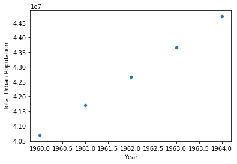

```python
# Use list comprehension to create new DataFrame column 'Total Urban Population'
df_pop_ceb['Total Urban Population'] = [int(tup[0] * tup[1]/100) for tup in pops_list]

# Plot urban population data
df_pop_ceb.plot(kind='scatter', x='Year', y='Total Urban Population')
plt.show()
```

### Writing an iterator to load data in chunks (4)

Now we will loop through the file chunks and append the data to get all of the data points

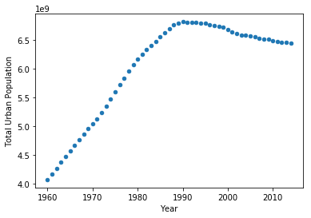

```python
# Initialize reader object: urb_pop_reader
urb_pop_reader = pd.read_csv(file_wb, chunksize=1000)

# Initialize empty DataFrame: data
data = pd.DataFrame()

# Iterate over each DataFrame chunk
for df_urb_pop in urb_pop_reader:

    # Check out specific country: df_pop_ceb
    df_pop_ceb = df_urb_pop[df_urb_pop['CountryCode'] == 'CEB']

    # Zip DataFrame columns of interest: pops
    pops = zip(df_pop_ceb['Total Population'],
                df_pop_ceb['Urban population (% of total)'])

    # Turn zip object into list: pops_list
    pops_list = list(pops)

    # Use list comprehension to create new DataFrame column 'Total Urban Population'
    df_pop_ceb['Total Urban Population'] = [int(tup[0] * tup[1]) for tup in pops_list]

    # Append DataFrame chunk to data: data
    data = data.append(df_pop_ceb)

# Plot urban population data
data.plot(kind='scatter', x='Year', y='Total Urban Population')
plt.show()
```

### Writing an iterator to load data in chunks (5)

And this is how we sould put this into a funciton and use it repeatedly

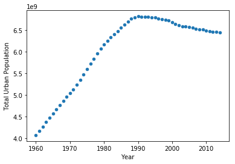

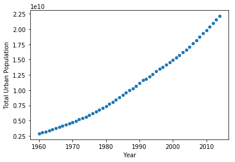

```python
# Define plot_pop()
def plot_pop(filename, country_code):

    # Initialize reader object: urb_pop_reader
    urb_pop_reader = pd.read_csv(filename, chunksize=1000)

    # Initialize empty DataFrame: data
    data = pd.DataFrame()

    # Iterate over each DataFrame chunk
    for df_urb_pop in urb_pop_reader:
        # Check out specific country: df_pop_ceb
        df_pop_ceb = df_urb_pop[df_urb_pop['CountryCode'] == country_code]

        # Zip DataFrame columns of interest: pops
        pops = zip(df_pop_ceb['Total Population'],
                    df_pop_ceb['Urban population (% of total)'])

        # Turn zip object into list: pops_list
        pops_list = list(pops)

        # Use list comprehension to create new DataFrame column 'Total Urban Population'
        df_pop_ceb['Total Urban Population'] = [int(tup[0] * tup[1]) for tup in pops_list]

        # Append DataFrame chunk to data: data
        data = data.append(df_pop_ceb)

    # Plot urban population data
    data.plot(kind='scatter', x='Year', y='Total Urban Population')
    plt.show()

# Set the filename: fn
fn = 'https://assets.datacamp.com/production/course_1531/datasets/world_ind_pop_data.csv'

# Call plot_pop for country code 'CEB'
plot_pop(fn, 'CEB')

# Call plot_pop for country code 'ARB'
plot_pop(fn, 'ARB')
```